# Comparison of Goodspeed metaprograms to the Sean Karl Cohort metaprograms

Ally Hawkins

2026-06-16

This notebook compares metaprograms generated from the Goodspeed public dataset to those from the full Sean Karl Cohort. For reference, the Goodspeed data has k=11 metaprograms and the full SKC has k=7 metaprograms. Note that 7 of these metaprograms are patient-specific, so we will only consider 4 metaprograms from the Goodspeed project.

This notebook requires files created from running `analyses/scripts/generate-mp-metrics.sh` and mirrors the analysis in `01-SCPCP000015-comparison.Rmd`.

## Set up

```r
library(ggplot2)
library(SingleCellExperiment)

# Set default ggplot theme
theme_set(
  theme_bw()
)
```

```r
# metaprogram metrics file
# contains comparison to metaprograms between the "subset" which is goodspeed
# and the full cohort which is the full SKC
data_dir <- here::here("data/goodspeed/full_cohort")
metrics_file <- file.path(data_dir, "SKC-metaprogram-comparison-metrics.tsv")

# paths to original mp objects and metrics objects
goodspeed_mp_file <- file.path(data_dir, "k-11_metaprograms.rds")
goodspeed_mp_metrics_file <- file.path(data_dir, "k-11_metaprograms-metrics.rds")

skc_mp_dir <- here::here("..", "ews-nf-out", "metaprograms", "metaprograms-7_cnmf-5-10-15_filtered")
skc_mp_file <-file.path(skc_mp_dir, "metaprograms.rds")
skc_mp_metrics_file <- file.path(skc_mp_dir, "k-7_metaprograms-metrics.rds")

# paths to score files, use these to look at the scores for the SKC metaprograms in goodspeed data
scores_dir <- file.path(data_dir, "scores")
score_files <- list.files(
  scores_dir,
  pattern = "_metaprogram-scores.tsv",
  full.names = TRUE,
  recursive = TRUE
)

# Read in SCE files
sce_dir <- here::here("data/goodspeed/processed_files")
sce_files <- list.files(
  sce_dir,
  pattern = "_processed.rds",
  full.names = TRUE,
  recursive = TRUE
)
sample_ids <- stringr::word(basename(sce_files), 1, sep = "_")
```

```r
# read in all the input files
metrics_df <- readr::read_tsv(metrics_file, col_types = list(.default = "d", subset_id = "c", subset_mp = "c", full_mp = "c"))

goodspeed_mps <- readr::read_rds(goodspeed_mp_file)
skc_mps <- readr::read_rds(skc_mp_file)

goodspeed_metrics <- readr::read_rds(goodspeed_mp_metrics_file)
skc_metrics <- readr::read_rds(skc_mp_metrics_file)

# read in all scores and combine into a single dataframe
scores_df <- score_files |>
  purrr::map(readr::read_tsv, col_types = list(.default = "c", mp_score = "d")) |>
  dplyr::bind_rows()


sce_list <- sce_files |>
  purrr::map(readr::read_rds) |>
  purrr::set_names(sample_ids)
```

## Identifying shared metaprograms

First, let’s just use the metrics we calculated to determine if any of the metaprograms are shared across both cohorts. We will use the correlation of the top 200 genes and the Jaccard index of the top 200 genes. We’ll use our cutoffs of Jaccard > 0.6 and top correlation > 0.75 that we defined previously.

As mentioned above, there are a number of patient-specific metaprograms in the Goodspeed data. We will remove those and only consider the other metaprograms.

```r
patient_specific_mps <- c("MP01", "MP02", "MP03", "MP07", "MP09", "MP10", "MP11")
metrics_df <- metrics_df |>
  dplyr::filter(!subset_mp %in% patient_specific_mps)

metrics_df |>
  dplyr::filter(
    jaccard >= 0.6,
    top_correlation >= 0.75
  )
```

| subset_id | optimal_k | subset_mp | full_mp | overall_correlation | top_correlation | jaccard |
| --- | --- | --- | --- | --- | --- | --- |

It doesn’t look like any programs are shared. What if we use our more lenient thresholds?

```r
metrics_df |>
  dplyr::filter(
    jaccard >= 0.3,
    top_correlation >= 0.5
  )
```

| subset_id | optimal_k | subset_mp | full_mp | overall_correlation | top_correlation | jaccard |
| --- | --- | --- | --- | --- | --- | --- |

Still no shared metaprograms. What’s the highest Jaccard we see?

```r
metrics_df |>
  dplyr::arrange(desc(jaccard)) |>
  head(n=20)
```

| subset_id | optimal_k | subset_mp | full_mp | overall_correlation | top_correlation | jaccard |
| --- | --- | --- | --- | --- | --- | --- |
| goodspeed | 11 | MP06 | MP06 | 0.540935658 | 0.1153239292 | 0.197604790 |
| goodspeed | 11 | MP08 | MP03 | 0.053291568 | 0.6589088556 | 0.017811705 |
| goodspeed | 11 | MP08 | MP02 | 0.030125762 | -0.0006812635 | 0.012658228 |
| goodspeed | 11 | MP05 | MP04 | 0.077562638 | -0.6432742119 | 0.010101010 |
| goodspeed | 11 | MP08 | MP04 | 0.083116087 | -0.6225723814 | 0.010101010 |
| goodspeed | 11 | MP05 | MP03 | 0.043009675 | 0.4501391746 | 0.007556675 |
| goodspeed | 11 | MP06 | MP03 | -0.103916168 | -0.8422353931 | 0.007556675 |
| goodspeed | 11 | MP08 | MP05 | 0.002654313 | 0.9949685137 | 0.007556675 |
| goodspeed | 11 | MP08 | MP01 | -0.062236902 | 1.0000000000 | 0.005025126 |
| goodspeed | 11 | MP05 | MP02 | 0.040609482 | 1.0000000000 | 0.005025126 |

[output cut: 10 more lines]

So the Jaccard index is generally low here.

## Overlap in gene sets from ORA

Let’s look at the intersection of the gene sets identified through ORA for each set of metaprograms. We’ll report both the Jaccard and the percentage of each gene sets from one cohort shared with the gene sets in the other cohort.

```r
# pull out the ora results
skc_ora_df <- skc_metrics$ora_results_df
goodspeed_ora_df <- goodspeed_metrics$ora_results_df
```

```r
# get all pairwise combinations of metaprograms
mp_combos <- expand.grid(
  skc = unique(skc_ora_df$metaprogram),
  goodspeed = unique(goodspeed_ora_df$metaprogram),
  stringsAsFactors = FALSE
) |>
  dplyr::filter(!goodspeed %in% patient_specific_mps)

# calculate jaccard and % overlap for each pair
ora_overlap_df <- mp_combos |>
  dplyr::mutate(
    # get a vector of gene sets for each metaprogram
    skc_genesets = purrr::map(
      skc, \(x) skc_ora_df$ID[skc_ora_df$metaprogram == x]
      ),
    goodspeed_genesets = purrr::map(
      goodspeed, \(x) goodspeed_ora_df$ID[goodspeed_ora_df$metaprogram == x]
      ),
    # calculate jaccard and % overlap
    intersection = purrr::map2_int(skc_genesets, goodspeed_genesets, \(x, y) length(intersect(x, y))),
    union = purrr::map2_int(skc_genesets, goodspeed_genesets, \(x, y) length(union(x, y))),
    jaccard = intersection / union,
    pct_overlap_skc = intersection / purrr::map_int(skc_genesets, length),
    pct_overlap_goodspeed = intersection / purrr::map_int(goodspeed_genesets, length)
  ) |>
  dplyr::select(-skc_genesets, -goodspeed_genesets)

ora_overlap_df |>
  dplyr::arrange(desc(jaccard))
```

| skc | goodspeed | intersection | union | jaccard | pct_overlap_skc | pct_overlap_goodspeed |
| --- | --- | --- | --- | --- | --- | --- |
| MP06 | MP06 | 53 | 157 | 0.337579618 | 0.34193548 | 0.96363636 |
| MP04 | MP05 | 13 | 133 | 0.097744361 | 0.14444444 | 0.23214286 |
| MP06 | MP04 | 21 | 218 | 0.096330275 | 0.13548387 | 0.25000000 |
| MP04 | MP08 | 22 | 254 | 0.086614173 | 0.24444444 | 0.11827957 |
| MP03 | MP08 | 17 | 264 | 0.064393939 | 0.17894737 | 0.09139785 |
| MP06 | MP08 | 19 | 322 | 0.059006211 | 0.12258065 | 0.10215054 |
| MP02 | MP05 | 5 | 94 | 0.053191489 | 0.11627907 | 0.08928571 |
| MP02 | MP08 | 10 | 219 | 0.045662100 | 0.23255814 | 0.05376344 |
| MP05 | MP08 | 5 | 194 | 0.025773196 | 0.38461538 | 0.02688172 |
| MP01 | MP06 | 1 | 62 | 0.016129032 | 0.12500000 | 0.01818182 |

[output cut: 18 more lines]

In this table, the `pct_overlap_skc` tells us what percentage of gene sets in the SKC metaprogram are also found in the goodspeed metaprograms and vice versa for `pct_overlap_goodspeed`.

It looks like 96% of genes returned for MP06 in Goodspeed are found in MP06 (cycling) for SKC. Outside of that, there’s not much similarity here.

## Use existing metaprograms to score SCEs

Another thing we can do is use the SKC metaprograms to score all tumor cells in the goodspeed cohort and see if there’s a) detectable scores for any metaprograms and b) any variation in the scores across cells. First, we’ll just look at the distribution of scores for each metaprogram.

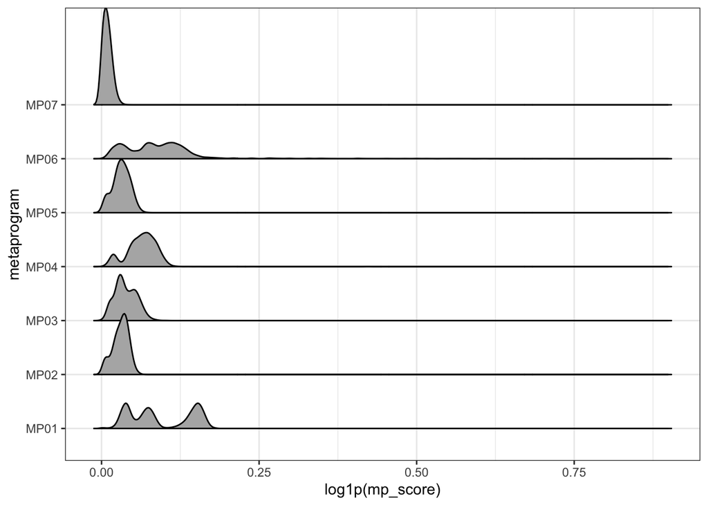

```r
ggplot(scores_df, aes(x = log1p(mp_score), y = metaprogram)) +
  ggridges::geom_density_ridges2()
```

I do see some variation in scores for MP01 and MP06.

What if we look at the scores for individual cells in a UMAP to see if we can find areas that have high scores for specific metaprograms? To do that, we first need to merge the SCE objects. To make a nicer UMAP, we’ll also integrate the samples using Harmony.

```r
prep_sce <- function(sce) {
  colnames(sce) <- glue::glue("{sce$sample_id}-{sce$barcodes}")
  sce$cell_id <- colnames(sce)
  return(sce)
}

sce_list <- sce_list |>
  purrr::map(prep_sce)

merged_sce <- do.call(cbind, c(unname(sce_list)))

sample_id_df <- colData(merged_sce) |>
  as.data.frame() |>
  dplyr::select(sample_id, sample_number) |>
  unique() |>
  tidyr::drop_na()

coldata_df <- colData(merged_sce) |>
  as.data.frame() |>
  dplyr::select(-sample_id) |>
  dplyr::left_join(sample_id_df, by = c("sample_number"))

colData(merged_sce) <- DataFrame(coldata_df, row.names = coldata_df$cell_id)
```

```r
# model gene variance
gene_var_block <- scran::modelGeneVar(
  merged_sce,
  block = merged_sce$sample_id
)
# identify subset of variable genes
hvg_list <- scran::getTopHVGs(
  gene_var_block,
  n = 2000
)

# multi batch PCA on merged object
multi_pca <- batchelor::multiBatchPCA(
  merged_sce,
  subset.row = hvg_list,
  batch = merged_sce$sample_id,
  preserve.single = TRUE
)

# add PCA results to merged SCE object
reducedDim(merged_sce, "PCA") <- multi_pca[[1]]

# add UMAP
merged_sce <- scater::runUMAP(
  merged_sce,
  dimred = "PCA"
)
```

```r
# read in the merged sce and integrate?
harmony_pca <- harmony::RunHarmony(
  data_mat = reducedDim(merged_sce, "PCA"),
  meta_data = colData(merged_sce),
  vars_use = c("sample_id")
)
```

```
Transposing data matrix
```

```
Initializing state using k-means centroids initialization
```

```
Harmony 1/10
```

```
Harmony 2/10
```

```
Harmony converged after 2 iterations
```

```r
# Store PCA as `harmony_PCA`
reducedDim(merged_sce, "harmony_PCA") <- harmony_pca

# calculate UMAP on this PCA matrix with appropriate names
merged_sce <- scater::runUMAP(merged_sce,
                              dimred = "harmony_PCA",
                              name   = "harmony_UMAP")
```

```r
# prep the scores dataframe for joining by adding a cell_id column
scores_df <- scores_df |>
  dplyr::mutate(
    cell_id = glue::glue("{unique_id}_Primary-{barcodes}")
  )

# combine UMAPs, scores, and annotations all together for plotting
all_info_df <- scater::makePerCellDF(
  merged_sce,
  use.dimred = "harmony_UMAP"
) |>
  dplyr::left_join(scores_df, by = c("cell_id", "barcodes"))

# extract just the tumor cells to plot
tumor_plot_df <- all_info_df |>
  dplyr::filter(
    stringr::str_detect(celltype_annotation, "Ewing sarcoma")
  )
```

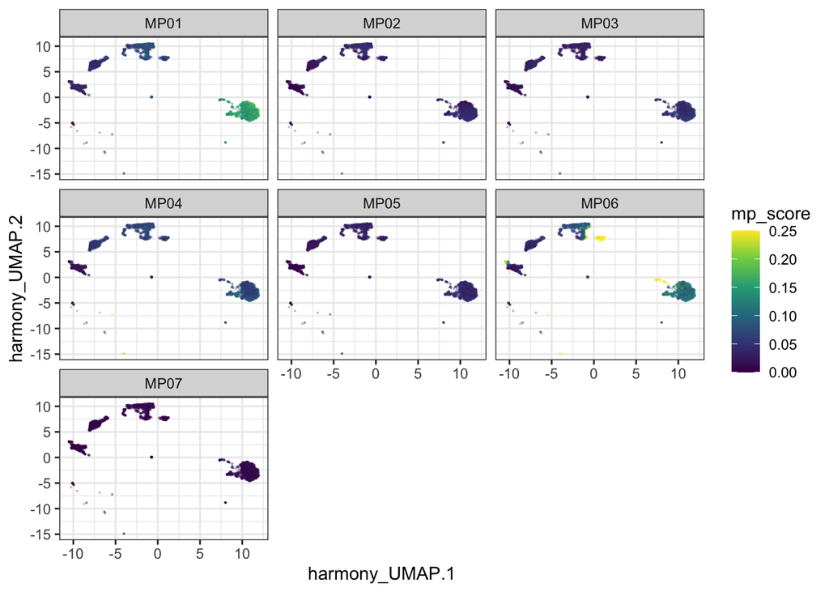

```r
ggplot(tumor_plot_df, aes(x = harmony_UMAP.1, y = harmony_UMAP.2, color = mp_score)) +
  geom_point(alpha = 0.2, size = 0.1) +
  facet_wrap(vars(metaprogram)) +
  # cap the scores since the majority of them are < 0.25
  scale_color_viridis_c(limits = c(0, 0.25), oob = scales::squish)
```

I actually do see a group of cells with MP01 and MP06 scores. I also see some evidence of MP04 I think?

### Using AUCell to score metaprograms

As a final ditch effort, let’s use `AUCell` with the 200 genes from each metaprogram to assign AUC values to each cell in our merged object. We can then plot the distribution of the AUC values to see if there is any evidence for activity of any of these gene sets.

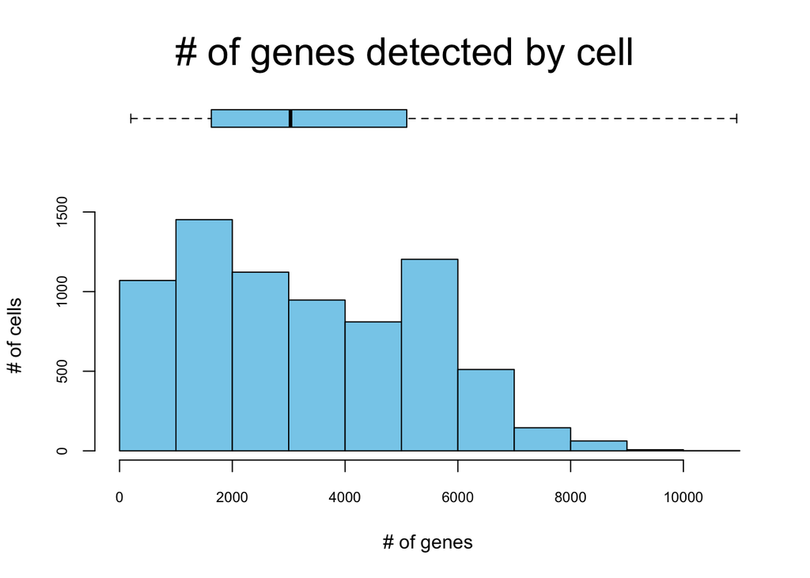

```
Quantiles for the number of genes detected by cell:
(Non-detected genes are shuffled at the end of the ranking. Keep it in mind when choosing the threshold for calculating the AUC).
```

```
     min       1%       5%      10%      50%     100%
  200.00   210.00   280.45   518.00  3032.00 10946.00
```

```r
# build rankings from SCE (only needs to be done once)
cell_rankings <- AUCell::AUCell_buildRankings(counts(merged_sce))
```

```r
# calculate AUC for all metaprograms at once
auc_scores <-AUCell::AUCell_calcAUC(
  skc_metrics$top_genes,
  aucMaxRank = ceiling(0.01 * nrow(cell_rankings)),
  cell_rankings
)
```

```
Genes in the gene sets NOT available in the dataset:
    MP01:   2 (1% of 200)
    MP02:   7 (4% of 200)
    MP03:   2 (1% of 200)
    MP04:   4 (2% of 200)
    MP05:   1 (0% of 200)
    MP06:   3 (2% of 200)
    MP07:   2 (1% of 200)
```

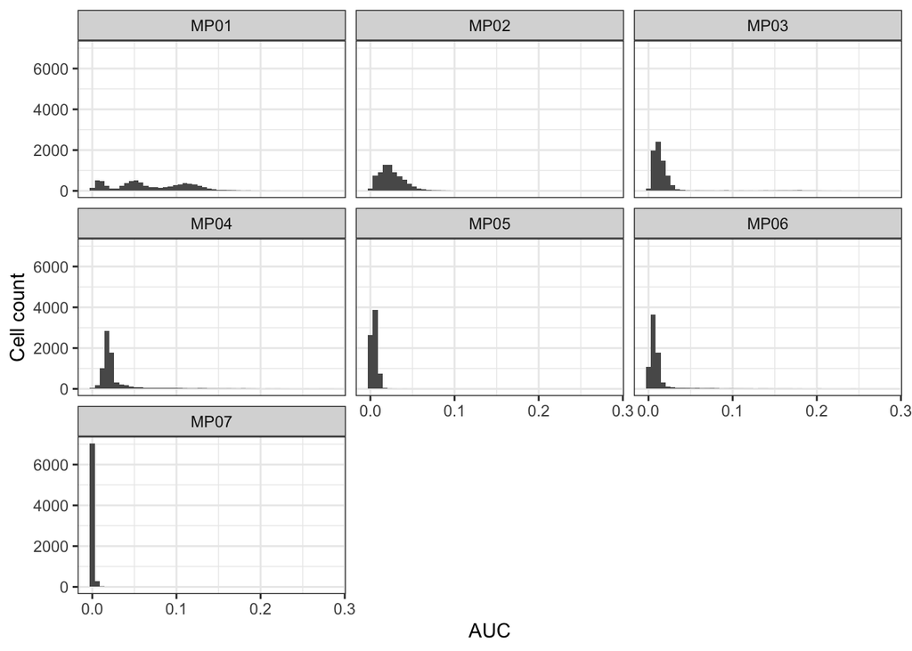

```r
# extract AUC matrix and plot distribution for each metaprogram
auc_df <- as.data.frame(t(assay(auc_scores))) |>
  tibble::rownames_to_column("cell_id") |>
  tidyr::pivot_longer(-cell_id, names_to = "metaprogram", values_to = "auc")

ggplot(auc_df, aes(x = auc)) +
  geom_histogram(bins = 50) +
  facet_wrap(vars(metaprogram)) +
  labs(x = "AUC", y = "Cell count") +
  theme_bw()
```

Consistent with the scoring, we see cells with higher AUC values in MP01 and then what looks like a tail of cells with higher MP06 and MP04.

## Conclusions

Similar to the ScPCA data, I think the only usable thing could be the UMAP where we look at scores for each of the SKC metaprograms. But that is still not overly impressive as we see mostly scores for EWS::FLI1 high and proliferative cells, which are expected given these are Ewing sarcoma cells.